# COPDGene/DECAMP Radiologic Clustering Project

Samuel Ash

2018-10-11

# 1 Overview

This document describes the initial results of the imaging clusters from COPDGene based on prior DECAMP clustering. This includes the baseline clinical characteristics and biomarkers as well as longitudinal analyses including change in FEV1, change in 6WMD, mortality, and exacerbation rates.

# 2 Load Libraries and Data

## 2.1 Libraries

## 2.2 Data

COPDGene datasets used include: 1) Baseline and longitudinal clinical dataset from October 9, 2017 2) Mortality dataset from December 2016 3) LFU dataset from July 2017 4) LH dataset from September 21, 2017 (using third set of LH training data) 5) RBM dataset 6) body composition dataset using manual measurements

# 3 Analysis

## 3.1 Clustering

Using k means (k=3 based on DECAMP). Note that the clusters are relabeled to correspond to the DECAMP clusters based on the local histogram characteristics.

### 3.1.1 Cluster appearance:

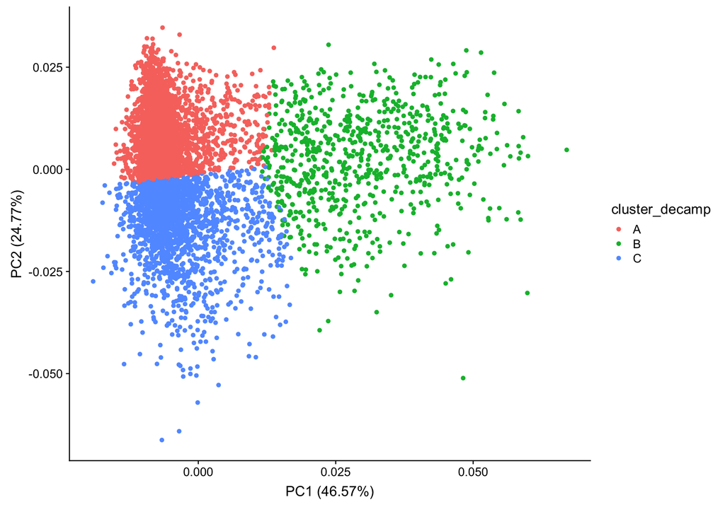

### 3.1.2 Comparison of clusters based on imaging characteristcs:

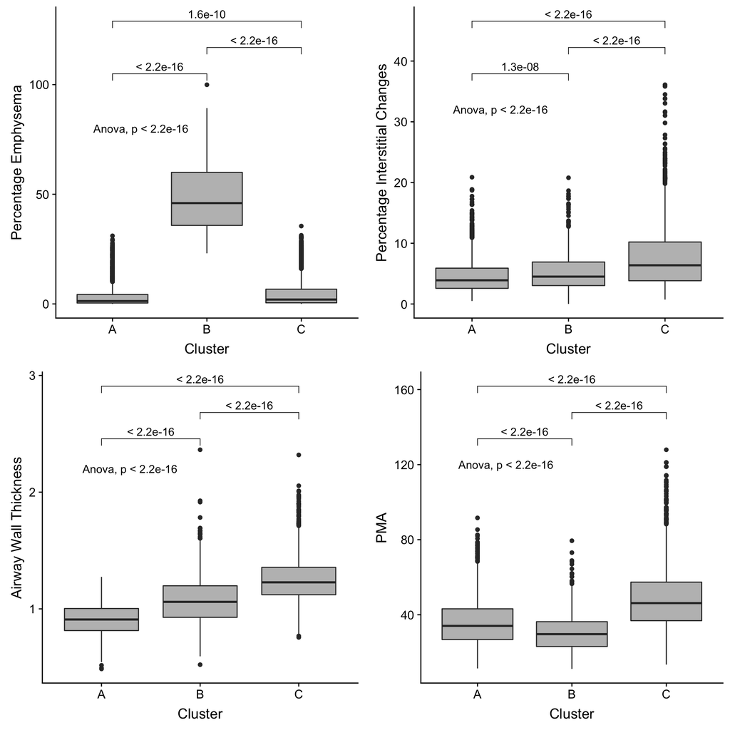

### 3.1.3 Mortality of the clusters

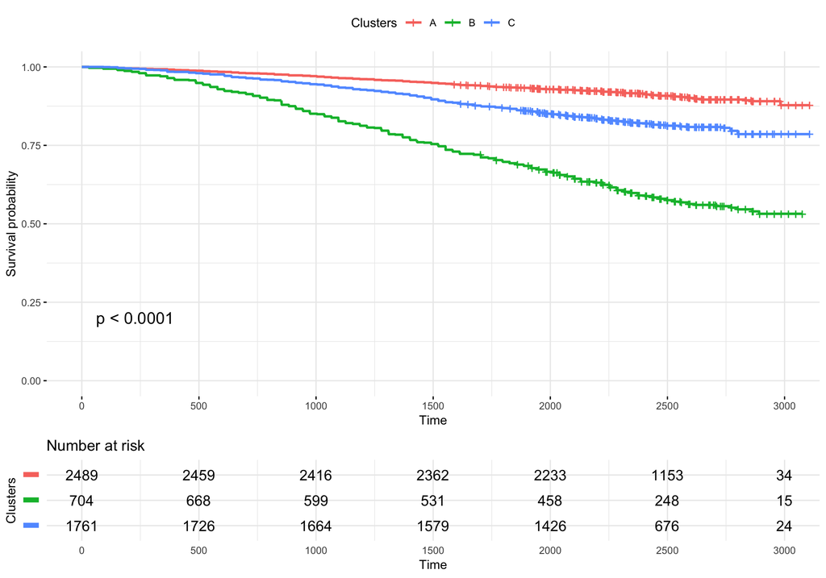

### 3.1.4 Comparison of clusters based on lung function, exercise capacity and quality of life

1. Baseline Values

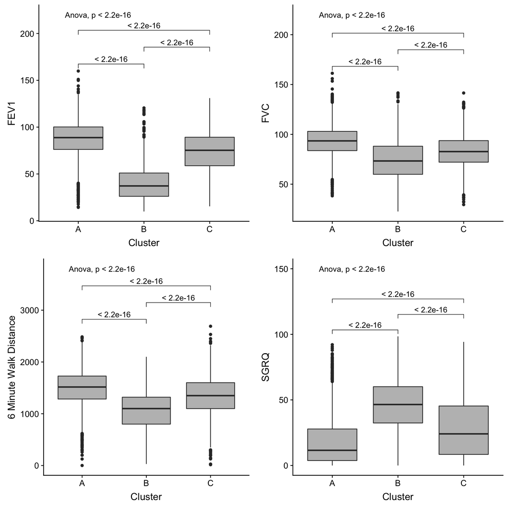

2. Progression over 5 Years of Follow Up

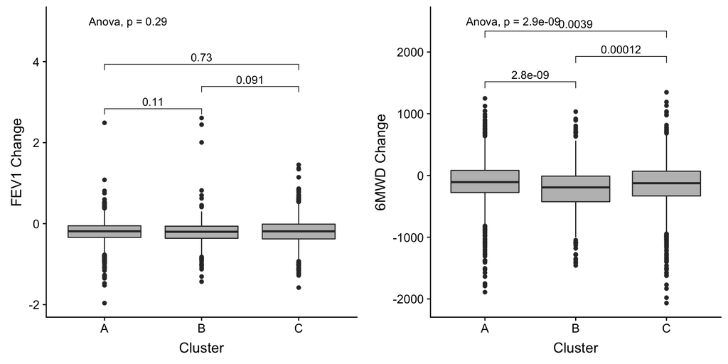

### 3.1.5 Exacerbation Rate by Cluster

Note that this comparison is only in those who reported at least one exacerbation during follow up

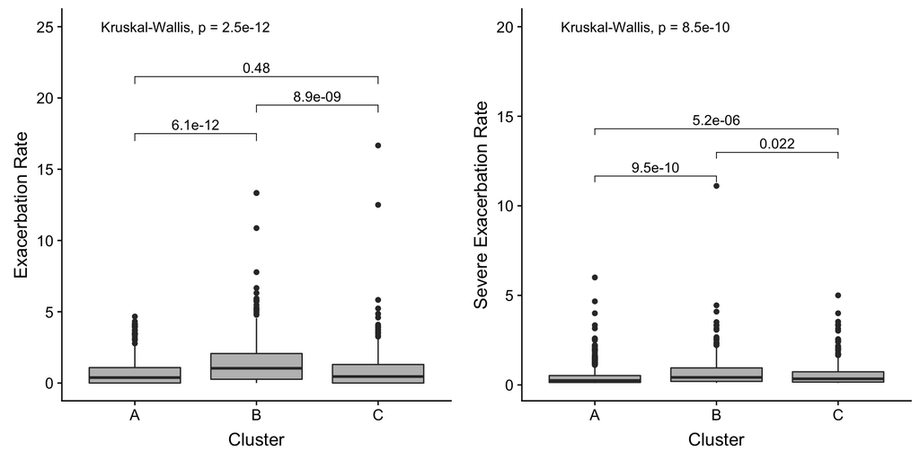

### 3.1.6 Selected Biomarkers by Cluster

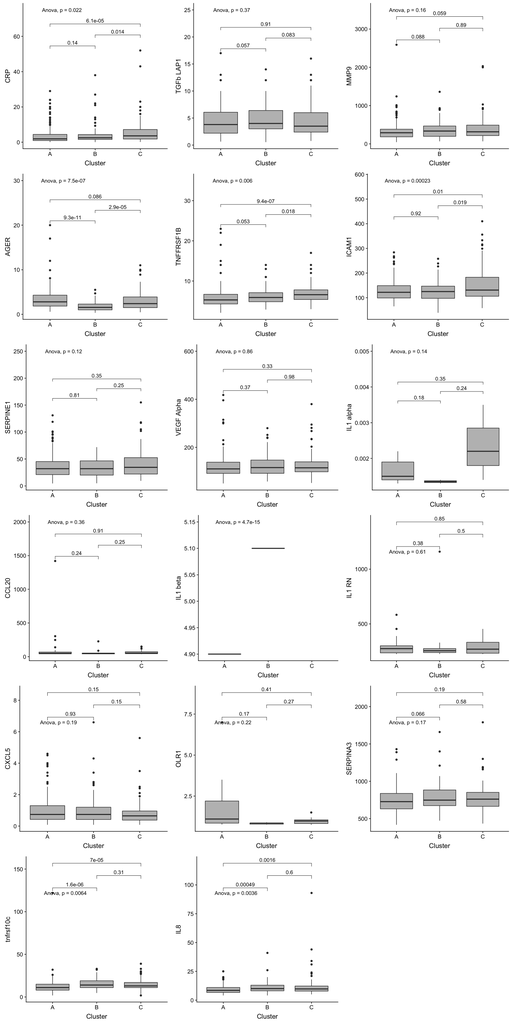